# Project Overview

The telecom operator, Interconnect, has a goal to predict churn of their clients. The clients that plan to leave will be offered promotional codes and special plan options.

**Goal:** Categorize clients into two groups:

- customers who will **NOT** churn
- customers who **WILL** churn

**Target:** EndDate

- A Date indicates the client has left
- No indicates the client is active

# Initialize

```python
import pandas as pd
import matplotlib.pyplot as plt
import seaborn as sns
```

# Load Data

```python
contracts = pd.read_csv('/datasets/final_provider/contract.csv')
personal = pd.read_csv('/datasets/final_provider/personal.csv')
internet = pd.read_csv('/datasets/final_provider/internet.csv')
phone = pd.read_csv('/datasets/final_provider/phone.csv')
```

# Explore Data

## Contracts Dataset

```python
# Contract: View general information
display(contracts.info())
display(contracts.head())

# Check Duplicated Data
print()
print("Number of Duplicated Rows:")
display(contracts.duplicated().sum())
print()
print("Number of Duplicated `customerID` rows:")
display(contracts['customerID'].duplicated().sum())
```

```
<class 'pandas.core.frame.DataFrame'>
RangeIndex: 7043 entries, 0 to 7042
Data columns (total 8 columns):
 #   Column            Non-Null Count  Dtype
---  ------            --------------  -----
 0   customerID        7043 non-null   object
 1   BeginDate         7043 non-null   object
 2   EndDate           7043 non-null   object
 3   Type              7043 non-null   object
 4   PaperlessBilling  7043 non-null   object
 5   PaymentMethod     7043 non-null   object
 6   MonthlyCharges    7043 non-null   float64
 7   TotalCharges      7043 non-null   object
dtypes: float64(1), object(7)
memory usage: 440.3+ KB
```

```
None
```

|  | customerID | BeginDate | EndDate | Type | PaperlessBilling | PaymentMethod | MonthlyCharges | TotalCharges |
| --- | --- | --- | --- | --- | --- | --- | --- | --- |
| 0 | 7590-VHVEG | 2020-01-01 | No | Month-to-month | Yes | Electronic check | 29.85 | 29.85 |
| 1 | 5575-GNVDE | 2017-04-01 | No | One year | No | Mailed check | 56.95 | 1889.5 |
| 2 | 3668-QPYBK | 2019-10-01 | 2019-12-01 00:00:00 | Month-to-month | Yes | Mailed check | 53.85 | 108.15 |
| 3 | 7795-CFOCW | 2016-05-01 | No | One year | No | Bank transfer (automatic) | 42.30 | 1840.75 |
| 4 | 9237-HQITU | 2019-09-01 | 2019-11-01 00:00:00 | Month-to-month | Yes | Electronic check | 70.70 | 151.65 |

```
Number of Duplicated Rows:
```

```
0
```

```
Number of Duplicated `customerID` rows:
```

```
0
```

```python
# Check values in each column
print("BeginDate Column Values:")
print("----------------------")
display(contracts['BeginDate'].value_counts())
print()
print("EndDate Column Values:")
print("----------------------")
display(contracts['EndDate'].value_counts())
print()
print("Type Column Values:")
print("----------------------")
display(contracts['Type'].value_counts())
print()
print("PaperlessBilling Column Values:")
print("----------------------")
display(contracts['PaperlessBilling'].value_counts())
print()
print("PyamentMethod Column Values:")
print("----------------------")
display(contracts['PaymentMethod'].value_counts())
print()
print("MonthlyCharges Column Values:")
print("----------------------")
display(contracts['MonthlyCharges'].value_counts())
print()
print("TotalCharges Column Values:")
print("----------------------")
display(contracts['TotalCharges'].value_counts())
print()
```

```
BeginDate Column Values:
----------------------
```

```
2014-02-01    366
2019-10-01    237
2019-09-01    237
2019-11-01    237
2020-01-01    233
             ...
2020-02-01     11
2014-01-01      7
2013-10-01      3
2013-12-01      3
2013-11-01      2
Name: BeginDate, Length: 77, dtype: int64
```

```
EndDate Column Values:
----------------------
```

```
No                     5174
2019-11-01 00:00:00     485
2019-12-01 00:00:00     466
2020-01-01 00:00:00     460
2019-10-01 00:00:00     458
Name: EndDate, dtype: int64
```

```
Type Column Values:
----------------------
```

```
Month-to-month    3875
Two year          1695
One year          1473
Name: Type, dtype: int64
```

```
PaperlessBilling Column Values:
----------------------
```

```
Yes    4171
No     2872
Name: PaperlessBilling, dtype: int64
```

```
PyamentMethod Column Values:
----------------------
```

```
Electronic check             2365
Mailed check                 1612
Bank transfer (automatic)    1544
Credit card (automatic)      1522
Name: PaymentMethod, dtype: int64
```

```
MonthlyCharges Column Values:
----------------------
```

```
20.05     61
19.85     45
19.90     44
19.95     44
19.65     43
          ..
87.65      1
35.30      1
114.85     1
56.50      1
97.25      1
Name: MonthlyCharges, Length: 1585, dtype: int64
```

```
TotalCharges Column Values:
----------------------
```

```
20.2       11
           11
19.75       9
19.65       8
20.05       8
           ..
5329.55     1
2021.35     1
4663.4      1
1728.2      1
6405        1
Name: TotalCharges, Length: 6531, dtype: int64
```

## Contracts Dataset Overview

| Dataset Information: |  |
| --- | --- |
| Total Entries: | 7043 |
| Missing Entries: | 0 |
| Duplicated Entries: | 0 |

1. **Standardize columns:**
   - All columns; Example: `customerID` --> `customer_id`, `BeginDate` --> `begin_date`
2. **Incorrect Dtypes:**
   - `BeginDate`: object --> datetime
     - `contracts['BeginDate'] = pd.to_datetime(contracts['BeginDate'])`
   - `EndDate`: object --> datetime
     - `contracts['EndDate'] = pd.to_datetime(contracts['EndDate'])`
   - `TotalCharges`: object --> float
     - `contracts['TotalCharges'] = pd.to_numeric(contracts['TotalCharges'], errors='coerce')`
     - `errors='coerce'` - turns problematic entries to `NaN`
3. **Feature Engineer:**
   - `customerID`: Leave as is
   - `BeginDate`: Extract month, year (not day: all days = 01)) for EDA
     - `contracts['begin_year'] = contracts['begindate'].dt.year`, `contracts['begin_month'] = contracts['begindate'].dt.month`
     - Once engineered get max and min month and year to get a general timeline of data collection
     - Drop for modeling after creating `tenure_months`
   - `EndDate`: No = 0 = Active; Date = 1 = NOT Active
     - 4 months make up ALL churned customers: 10/2019, 11/2019, 12/2019, 01/2020
     - drop for modeling - create churned instead
   - Create `churned`: Use `EndDate` to determine if the customer has churned or not
   - Create `tenure_months` for modeling (`EndDate`(no EndDate = February 2020) - `BeginDate`)
   - `Type`: Rows not necessary to standardize (`Month-to-month`, `Two year`, `One year`)
     - Consider OHE: `pd.get_dummies(contracts, columns=['Type'], drop_first=True)` **Not Recommended for CatBoost**
   - `PaperlessBilling`: Rows not necessary to standardize (Yes/No)
     - Consider Binary Encoding: `contracts['PaperlessBilling'] = contracts['PaperlessBilling'].map({'Yes':1, 'No':0})`
   - `PaymentMethod`: Rows not necessary to standardize (`Bank transfer (automatic)`, `Credit card (automatic)`, `Electronic check`, `Mailed check`)
     - Consider OHE: `pd.get_dummies(contracts, columns=['PaymentMethod'], drop_first=True)` **Not Recommended for CatBoost**
   - `MonthlyCharges`: Leave as is
   - `TotalCharges`: Leave as is (after changing to float dtype)

## Personal Dataset

```python
# personal
display(personal.info())
display(personal.head())

# Check for duplicated data
print()
print("Number of Duplicated rows:")
display(personal.duplicated().sum())
print()
print("Number of Duplicated `customerID` rows:")
display(personal['customerID'].duplicated().sum())
```

```
<class 'pandas.core.frame.DataFrame'>
RangeIndex: 7043 entries, 0 to 7042
Data columns (total 5 columns):
 #   Column         Non-Null Count  Dtype
---  ------         --------------  -----
 0   customerID     7043 non-null   object
 1   gender         7043 non-null   object
 2   SeniorCitizen  7043 non-null   int64
 3   Partner        7043 non-null   object
 4   Dependents     7043 non-null   object
dtypes: int64(1), object(4)
memory usage: 275.2+ KB
```

```
None
```

|  | customerID | gender | SeniorCitizen | Partner | Dependents |
| --- | --- | --- | --- | --- | --- |
| 0 | 7590-VHVEG | Female | 0 | Yes | No |
| 1 | 5575-GNVDE | Male | 0 | No | No |
| 2 | 3668-QPYBK | Male | 0 | No | No |
| 3 | 7795-CFOCW | Male | 0 | No | No |
| 4 | 9237-HQITU | Female | 0 | No | No |

```
Number of Duplicated rows:
```

```
0
```

```
Number of Duplicated `customerID` rows:
```

```
0
```

```python
# Check values in each column
print("gender Column Values:")
print("----------------------")
display(personal['gender'].value_counts())
print()
print("SeniorCitizen Column Values:")
print("----------------------")
display(personal['SeniorCitizen'].value_counts())
print()
print("Partner Column Values:")
print("----------------------")
display(personal['Partner'].value_counts())
print()
print("Dependents Column Values:")
print("----------------------")
display(personal['Dependents'].value_counts())
print()
```

```
gender Column Values:
----------------------
```

```
Male      3555
Female    3488
Name: gender, dtype: int64
```

```
SeniorCitizen Column Values:
----------------------
```

```
0    5901
1    1142
Name: SeniorCitizen, dtype: int64
```

```
Partner Column Values:
----------------------
```

```
No     3641
Yes    3402
Name: Partner, dtype: int64
```

```
Dependents Column Values:
----------------------
```

```
No     4933
Yes    2110
Name: Dependents, dtype: int64
```

## Personal Dataset Overview

| Dataset Information: |  |
| --- | --- |
| Total Entries: | 7043 |
| Missing Entries: | 0 |
| Duplicated Entries: | 0 |

## Internet Dataset

```python
# internet
display(internet.info())
display(internet.head())

# Check for duplicated data
print()
print("Number of Duplicated rows:")
display(internet.duplicated().sum())
print()
print("Number of Duplicated `customerID` rows:")
display(internet['customerID'].duplicated().sum())
```

```
<class 'pandas.core.frame.DataFrame'>
RangeIndex: 5517 entries, 0 to 5516
Data columns (total 8 columns):
 #   Column            Non-Null Count  Dtype
---  ------            --------------  -----
 0   customerID        5517 non-null   object
 1   InternetService   5517 non-null   object
 2   OnlineSecurity    5517 non-null   object
 3   OnlineBackup      5517 non-null   object
 4   DeviceProtection  5517 non-null   object
 5   TechSupport       5517 non-null   object
 6   StreamingTV       5517 non-null   object
 7   StreamingMovies   5517 non-null   object
dtypes: object(8)
memory usage: 344.9+ KB
```

```
None
```

|  | customerID | InternetService | OnlineSecurity | OnlineBackup | DeviceProtection | TechSupport | StreamingTV | StreamingMovies |
| --- | --- | --- | --- | --- | --- | --- | --- | --- |
| 0 | 7590-VHVEG | DSL | No | Yes | No | No | No | No |
| 1 | 5575-GNVDE | DSL | Yes | No | Yes | No | No | No |
| 2 | 3668-QPYBK | DSL | Yes | Yes | No | No | No | No |
| 3 | 7795-CFOCW | DSL | Yes | No | Yes | Yes | No | No |
| 4 | 9237-HQITU | Fiber optic | No | No | No | No | No | No |

```
Number of Duplicated rows:
```

```
0
```

```
Number of Duplicated `customerID` rows:
```

```
0
```

```python
# Check values in each column
print("InternetService Column Values:")
print("----------------------")
display(internet['InternetService'].value_counts())
print()
print("OnlineSecurity Column Values:")
print("----------------------")
display(internet['OnlineSecurity'].value_counts())
print()
print("OnlineBackup Column Values:")
print("----------------------")
display(internet['OnlineBackup'].value_counts())
print()
print("DeviceProtection Column Values:")
print("----------------------")
display(internet['DeviceProtection'].value_counts())
print()
print("TechSupport Column Values:")
print("----------------------")
display(internet['TechSupport'].value_counts())
print()
print("StreamingTV Column Values:")
print("----------------------")
display(internet['StreamingTV'].value_counts())
print()
print("StreamingMovies Column Values:")
print("----------------------")
display(internet['StreamingMovies'].value_counts())
print()
```

```
InternetService Column Values:
----------------------
```

```
Fiber optic    3096
DSL            2421
Name: InternetService, dtype: int64
```

```
OnlineSecurity Column Values:
----------------------
```

```
No     3498
Yes    2019
Name: OnlineSecurity, dtype: int64
```

```
OnlineBackup Column Values:
----------------------
```

```
No     3088
Yes    2429
Name: OnlineBackup, dtype: int64
```

```
DeviceProtection Column Values:
----------------------
```

```
No     3095
Yes    2422
Name: DeviceProtection, dtype: int64
```

```
TechSupport Column Values:
----------------------
```

```
No     3473
Yes    2044
Name: TechSupport, dtype: int64
```

```
StreamingTV Column Values:
----------------------
```

```
No     2810
Yes    2707
Name: StreamingTV, dtype: int64
```

```
StreamingMovies Column Values:
----------------------
```

```
No     2785
Yes    2732
Name: StreamingMovies, dtype: int64
```

## Internet Dataset Overview

| Dataset Information: |  |
| --- | --- |
| Total Entries: | 5517 |
| Missing Entries: | **1,526** |
| Duplicated Entries: | 0 |

**Note:** First two dataframes had 7,043 entries; this dataframe has 5,517. This is how I calculated **1,526** missing entries (21.7%)

1. **Standardize columns:**
   - All columns; Example: `customerID` --> `customer_id`, `InternetService` --> `internet_service`
2. **Incorrect Dtypes:**
   - None: Binary Encoding should change the dtype to 'int'
3. **Feature Engineer:**
   - `customerID`: Leave as is
   - `InternetService`:
     - Consider Binary Encoding: `internet['InternetService'] = internet['InternetService'].map({'DSL':1, 'Fiber optic':0})`
     - **Note:** Since Female is typically marked as 0, I've chosen to mark Fiber Optic as 0 to easily remember that both words starting with 'F' get the same value
   - `OnlineSecurity`:
     - Consider Binary Encoding: `internet['OnlineSecurity'] = internet['OnlineSecurity'].map({'Yes':1, 'No':0})`
   - `OnlineBackup`:
     - Consider Binary Encoding: `internet['OnlineBackup'] = internet['OnlineBackup'].map({'Yes':1, 'No':0})`
   - `DeviceProtection`:
     - Consider Binary Encoding: `internet['DeviceProtection'] = internet['DeviceProtection'].map({'Yes':1, 'No':0})`
   - `TechSupport`:
     - Consider Binary Encoding: `internet['TechSupport'] = internet['TechSupport'].map({'Yes':1, 'No':0})`
   - `StreamingTV`:
     - Consider Binary Encoding: `internet['StreamingTV'] = internet['StreamingTV'].map({'Yes':1, 'No':0})`
   - `StreamingMovie`:
     - Consider Binary Encoding: `internet['StreamingMovie'] = internet['StreamingMovie'].map({'Yes':1, 'No':0})`

## Phone Dataset

```python
# phone
display(phone.info())
display(phone.head())

# Check for duplicated data
print()
print("Number of Duplicated rows:")
display(phone.duplicated().sum())
print()
print("Number of Duplicated `customerID` rows:")
display(phone['customerID'].duplicated().sum())
```

```
<class 'pandas.core.frame.DataFrame'>
RangeIndex: 6361 entries, 0 to 6360
Data columns (total 2 columns):
 #   Column         Non-Null Count  Dtype
---  ------         --------------  -----
 0   customerID     6361 non-null   object
 1   MultipleLines  6361 non-null   object
dtypes: object(2)
memory usage: 99.5+ KB
```

```
None
```

|  | customerID | MultipleLines |
| --- | --- | --- |
| 0 | 5575-GNVDE | No |
| 1 | 3668-QPYBK | No |
| 2 | 9237-HQITU | No |
| 3 | 9305-CDSKC | Yes |
| 4 | 1452-KIOVK | Yes |

```
Number of Duplicated rows:
```

```
0
```

```
Number of Duplicated `customerID` rows:
```

```
0
```

```python
# Check values in each column
print("MultipleLines Column Values:")
print("----------------------")
display(phone['MultipleLines'].value_counts())
print()
```

```
MultipleLines Column Values:
----------------------
```

```
No     3390
Yes    2971
Name: MultipleLines, dtype: int64
```

## Phone Dataset Overview

| Dataset Information: |  |
| --- | --- |
| Total Entries: | 6361 |
| Missing Entries: | **682** |
| Duplicated Entries: | 0 |

**Note:** First two dataframes had 7,043 entries; this dataframe has 6,361. This is how I calculated **682** missing entries (9.7%).

1. **Standardize columns:**
   - All columns; Example: `customerID` --> `customer_id`, `MultipleLines` --> `multiple_lines`
2. **Incorrect Dtypes:**
   - None: Binary Encoding should change the dtype to 'int'
3. **Feature Engineer:**
   - `customerID`: Leave as is
   - `MultipleLines`:
     - Consider Binary Encoding: `phone['MultipleLines'] = phone['MultipleLines'].map({'Yes':1, 'No':0})`

# Preprocessing

## Standardize columns:

```python
# Contracts
# customerID	BeginDate	EndDate	Type	PaperlessBilling	PaymentMethod	MonthlyCharges	TotalCharges
contracts_cols = {'customerID': 'customer_id',
                  'BeginDate': 'begin_date',
                  'EndDate': 'end_date',
                  'Type': 'type',
                  'PaperlessBilling': 'paperless_billing',
                  'PaymentMethod': 'payment_method',
                  'MonthlyCharges': 'monthly_charges',
                  'TotalCharges': 'total_charges'}

contracts.rename(columns=(contracts_cols), inplace=True)
print("Contract Dataset Column Names")
print("-----------------------------")
display(contracts.columns.to_list())
print()
# Personal
# 'customerID', 'SeniorCitizen', 'Partner', 'Dependents'
personal_cols = {'customerID': 'customer_id',
                 'SeniorCitizen': 'senior_citizen',
                 'Partner': 'partner',
                 'Dependents': 'dependents'}

personal.rename(columns=(personal_cols), inplace=True)
print("Personal Dataset Column Names")
print("-----------------------------")
display(personal.columns.to_list())
print()

# Internet
# 'customerID', 'InternetService', 'OnlineSecurity', 'OnlineBackup', 'DeviceProtection', 'TechSupport', 'StreamingTV', 'StreamingMovies'
internet_cols = {'customerID': 'customer_id',
                 'InternetService': 'internet_service',
                 'OnlineSecurity': 'online_security',
                 'OnlineBackup': 'online_backup',
                 'DeviceProtection': 'device_protection',
                 'TechSupport': 'tech_support',
                 'StreamingTV': 'streaming_tv',
                 'StreamingMovies': 'streaming_movies'}

internet.rename(columns=(internet_cols), inplace=True)
print("Internet Dataset Column Names")
print("-----------------------------")
display(internet.columns.to_list())
print()

# Phone
# 'customerID', 'MultipleLines'
phone_cols = {'customerID': 'customer_id',
              'MultipleLines': 'multiple_lines'}

phone.rename(columns=(phone_cols), inplace = True)
print("Phone Dataset Column Names")
print("-----------------------------")
display(phone.columns.to_list())
print()
```

```
Contract Dataset Column Names
-----------------------------
```

```
['customer_id',
 'begin_date',
 'end_date',
 'type',
 'paperless_billing',
 'payment_method',
 'monthly_charges',
 'total_charges']
```

```
Personal Dataset Column Names
-----------------------------
```

```
['customer_id', 'gender', 'senior_citizen', 'partner', 'dependents']
```

```
Internet Dataset Column Names
-----------------------------
```

```
['customer_id',
 'internet_service',
 'online_security',
 'online_backup',
 'device_protection',
 'tech_support',
 'streaming_tv',
 'streaming_movies']
```

```
Phone Dataset Column Names
-----------------------------
```

```
['customer_id', 'multiple_lines']
```

## Dtype Correction:

```python
# Ensure correct dtypes

# Contracts Dataset
contracts['begin_date'] = pd.to_datetime(contracts['begin_date'])
contracts['end_date'] = pd.to_datetime(contracts['end_date'], errors='coerce') # errors='coerce': problem entries to Nan
contracts['total_charges'] = pd.to_numeric(contracts['total_charges'], errors='coerce')
print("Contracts Dataset")
print("--------------------------------------------------")
display(contracts.info())
print()

# Personal Dataset
personal['senior_citizen'] = pd.to_numeric(personal['senior_citizen'], errors='coerce')
print("Personal Dataset")
print("--------------------------------------------------")
display(personal.info())

# Internet & Phone do not require dtype corrections
```

```
Contracts Dataset
--------------------------------------------------
<class 'pandas.core.frame.DataFrame'>
RangeIndex: 7043 entries, 0 to 7042
Data columns (total 8 columns):
 #   Column             Non-Null Count  Dtype
---  ------             --------------  -----
 0   customer_id        7043 non-null   object
 1   begin_date         7043 non-null   datetime64[ns]
 2   end_date           1869 non-null   datetime64[ns]
 3   type               7043 non-null   object
 4   paperless_billing  7043 non-null   object
 5   payment_method     7043 non-null   object
 6   monthly_charges    7043 non-null   float64
 7   total_charges      7032 non-null   float64
dtypes: datetime64[ns](2), float64(2), object(4)
memory usage: 440.3+ KB
```

```
None
```

```
Personal Dataset
--------------------------------------------------
<class 'pandas.core.frame.DataFrame'>
RangeIndex: 7043 entries, 0 to 7042
Data columns (total 5 columns):
 #   Column          Non-Null Count  Dtype
---  ------          --------------  -----
 0   customer_id     7043 non-null   object
 1   gender          7043 non-null   object
 2   senior_citizen  7043 non-null   int64
 3   partner         7043 non-null   object
 4   dependents      7043 non-null   object
dtypes: int64(1), object(4)
memory usage: 275.2+ KB
```

```
None
```

## Feature Engineering

```python
# Contracts Dataset

# Binary Encoding for 'paperless_billing',
contracts['paperless_billing'] = contracts['paperless_billing'].map({'Yes':1, 'No': 0})

print("Contracts Dataset")
print("--------------------------------------------------")
display(contracts.info())
display(contracts.head())
print()


# Personal Dataset

# Binary Encoding for 'gender', 'partner', and 'dependents'
personal_col = ['partner', 'dependents']

for col in personal_col:
    personal[col] = personal[col].map({'Yes': 1, 'No': 0})

personal['gender'] = personal['gender'].map({'Male': 1, 'Female': 0})

print("Personal Dataset")
print("--------------------------------------------------")
display(personal.info())
display(personal.head())
print()


# Internet

# Binary Encoding for 'internet_service', 'online_security', 'online_backup', 'device_protection', 'tech_support', 'streaming_tv', 'streaming_movies'
internet_col = ['online_security', 'online_backup', 'device_protection', 'tech_support', 'streaming_tv', 'streaming_movies']

for col in internet_col:
    internet[col] = internet[col].map({'Yes':1, 'No':0})

internet['internet_service'] = internet['internet_service'].map({'DSL': 1, 'Fiber optic': 0})

print("Internet Dataset")
print("--------------------------------------------------")
display(internet.info())
display(internet.head())
print()


# Phone

# Binary Encoding for 'multiple_lines'
phone['multiple_lines'] = phone['multiple_lines'].map({'Yes': 1, 'No': 0})

print("Phone Dataset")
print("--------------------------------------------------")
display(phone.info())
display(phone.head())
print()
```

```
Contracts Dataset
--------------------------------------------------
<class 'pandas.core.frame.DataFrame'>
RangeIndex: 7043 entries, 0 to 7042
Data columns (total 8 columns):
 #   Column             Non-Null Count  Dtype
---  ------             --------------  -----
 0   customer_id        7043 non-null   object
 1   begin_date         7043 non-null   datetime64[ns]
 2   end_date           1869 non-null   datetime64[ns]
 3   type               7043 non-null   object
 4   paperless_billing  7043 non-null   int64
 5   payment_method     7043 non-null   object
 6   monthly_charges    7043 non-null   float64
 7   total_charges      7032 non-null   float64
dtypes: datetime64[ns](2), float64(2), int64(1), object(3)
memory usage: 440.3+ KB
```

```
None
```

|  | customer_id | begin_date | end_date | type | paperless_billing | payment_method | monthly_charges | total_charges |
| --- | --- | --- | --- | --- | --- | --- | --- | --- |
| 0 | 7590-VHVEG | 2020-01-01 | NaT | Month-to-month | 1 | Electronic check | 29.85 | 29.85 |
| 1 | 5575-GNVDE | 2017-04-01 | NaT | One year | 0 | Mailed check | 56.95 | 1889.50 |
| 2 | 3668-QPYBK | 2019-10-01 | 2019-12-01 | Month-to-month | 1 | Mailed check | 53.85 | 108.15 |
| 3 | 7795-CFOCW | 2016-05-01 | NaT | One year | 0 | Bank transfer (automatic) | 42.30 | 1840.75 |
| 4 | 9237-HQITU | 2019-09-01 | 2019-11-01 | Month-to-month | 1 | Electronic check | 70.70 | 151.65 |

```
Personal Dataset
--------------------------------------------------
<class 'pandas.core.frame.DataFrame'>
RangeIndex: 7043 entries, 0 to 7042
Data columns (total 5 columns):
 #   Column          Non-Null Count  Dtype
---  ------          --------------  -----
 0   customer_id     7043 non-null   object
 1   gender          7043 non-null   int64
 2   senior_citizen  7043 non-null   int64
 3   partner         7043 non-null   int64
 4   dependents      7043 non-null   int64
dtypes: int64(4), object(1)
memory usage: 275.2+ KB
```

```
None
```

|  | customer_id | gender | senior_citizen | partner | dependents |
| --- | --- | --- | --- | --- | --- |
| 0 | 7590-VHVEG | 0 | 0 | 1 | 0 |
| 1 | 5575-GNVDE | 1 | 0 | 0 | 0 |
| 2 | 3668-QPYBK | 1 | 0 | 0 | 0 |
| 3 | 7795-CFOCW | 1 | 0 | 0 | 0 |
| 4 | 9237-HQITU | 0 | 0 | 0 | 0 |

```
Internet Dataset
--------------------------------------------------
<class 'pandas.core.frame.DataFrame'>
RangeIndex: 5517 entries, 0 to 5516
Data columns (total 8 columns):
 #   Column             Non-Null Count  Dtype
---  ------             --------------  -----
 0   customer_id        5517 non-null   object
 1   internet_service   5517 non-null   int64
 2   online_security    5517 non-null   int64
 3   online_backup      5517 non-null   int64
 4   device_protection  5517 non-null   int64
 5   tech_support       5517 non-null   int64
 6   streaming_tv       5517 non-null   int64
 7   streaming_movies   5517 non-null   int64
dtypes: int64(7), object(1)
memory usage: 344.9+ KB
```

```
None
```

|  | customer_id | internet_service | online_security | online_backup | device_protection | tech_support | streaming_tv | streaming_movies |
| --- | --- | --- | --- | --- | --- | --- | --- | --- |
| 0 | 7590-VHVEG | 1 | 0 | 1 | 0 | 0 | 0 | 0 |
| 1 | 5575-GNVDE | 1 | 1 | 0 | 1 | 0 | 0 | 0 |
| 2 | 3668-QPYBK | 1 | 1 | 1 | 0 | 0 | 0 | 0 |
| 3 | 7795-CFOCW | 1 | 1 | 0 | 1 | 1 | 0 | 0 |
| 4 | 9237-HQITU | 0 | 0 | 0 | 0 | 0 | 0 | 0 |

```
Phone Dataset
--------------------------------------------------
<class 'pandas.core.frame.DataFrame'>
RangeIndex: 6361 entries, 0 to 6360
Data columns (total 2 columns):
 #   Column          Non-Null Count  Dtype
---  ------          --------------  -----
 0   customer_id     6361 non-null   object
 1   multiple_lines  6361 non-null   int64
dtypes: int64(1), object(1)
memory usage: 99.5+ KB
```

```
None
```

|  | customer_id | multiple_lines |
| --- | --- | --- |
| 0 | 5575-GNVDE | 0 |
| 1 | 3668-QPYBK | 0 |
| 2 | 9237-HQITU | 0 |
| 3 | 9305-CDSKC | 1 |
| 4 | 1452-KIOVK | 1 |

```python
# Contracts

# Extract month and year from 'begin_date' for EDA
contracts['begin_month'] = contracts['begin_date'].dt.month
contracts['begin_year'] = contracts['begin_date'].dt.year
print("Minimum Month/Year for Client Start Date")
min_year = contracts['begin_year'].min()
contract_min = contracts[(contracts['begin_year'] == 2013)]
min_month = contract_min['begin_month'].min()
display(f"Month: {min_month}, Year: {min_year}")
print()
print("Maximum Month/Year for Client Start Date")
max_year = contracts['begin_year'].max()
contract_max = contracts[(contracts['begin_year'] == 2020)]
max_month = contract_max['begin_month'].max()
display(f"Month: {max_month}, Year: {max_year}")
```

```
Minimum Month/Year for Client Start Date
```

```
'Month: 10, Year: 2013'
```

```
Maximum Month/Year for Client Start Date
```

```
'Month: 2, Year: 2020'
```

```python
# Contracts

# Create `churned` column from `end_date` column
# No = 0 = Active; Date = 1 = NOT Active

contracts['churned'] = contracts['end_date'].notna().astype(int)
```

```python
# Create `tenure_months` - how many months a customer has been with the company
# No end_date = February, 2020

# Create temporary end_date
reference_date_active = pd.to_datetime('2020-02-01')
contracts['effective_end_date'] = contracts['end_date'].fillna(reference_date_active)
display(contracts.head())

# Get the length of time a customer has stayed in months - have to calculate using .dt.year and .dt.month separately
# Example: begin[2015-09] - end[2020-02] = 4 years and 5 months = 53 months
    # figure year: 2020 - 2015 = 5 years (convert to months by multiplying by 12) = 60 months
    # figure months: 02 months - 09 months = (-)7 months
    # Put it together: 2020 - 2015 = 5 years * 12 months = 60 months + (2 months - 9 months = (-)7 months) = 60 -7 = 53 months

contracts['tenure_months'] = ((contracts['effective_end_date'].dt.year - contracts['begin_date'].dt.year) * 12) + (contracts['effective_end_date'].dt.month - contracts['begin_date'].dt.month)

# Drop the temporary 'effective_end_date' column
contracts.drop(columns=('effective_end_date'), inplace = True)
display(contracts.head())
```

|  | customer_id | begin_date | end_date | type | paperless_billing | payment_method | monthly_charges | total_charges | begin_month | begin_year | churned | effective_end_date |
| --- | --- | --- | --- | --- | --- | --- | --- | --- | --- | --- | --- | --- |
| 0 | 7590-VHVEG | 2020-01-01 | NaT | Month-to-month | 1 | Electronic check | 29.85 | 29.85 | 1 | 2020 | 0 | 2020-02-01 |
| 1 | 5575-GNVDE | 2017-04-01 | NaT | One year | 0 | Mailed check | 56.95 | 1889.50 | 4 | 2017 | 0 | 2020-02-01 |
| 2 | 3668-QPYBK | 2019-10-01 | 2019-12-01 | Month-to-month | 1 | Mailed check | 53.85 | 108.15 | 10 | 2019 | 1 | 2019-12-01 |
| 3 | 7795-CFOCW | 2016-05-01 | NaT | One year | 0 | Bank transfer (automatic) | 42.30 | 1840.75 | 5 | 2016 | 0 | 2020-02-01 |
| 4 | 9237-HQITU | 2019-09-01 | 2019-11-01 | Month-to-month | 1 | Electronic check | 70.70 | 151.65 | 9 | 2019 | 1 | 2019-11-01 |

|  | customer_id | begin_date | end_date | type | paperless_billing | payment_method | monthly_charges | total_charges | begin_month | begin_year | churned | tenure_months |
| --- | --- | --- | --- | --- | --- | --- | --- | --- | --- | --- | --- | --- |
| 0 | 7590-VHVEG | 2020-01-01 | NaT | Month-to-month | 1 | Electronic check | 29.85 | 29.85 | 1 | 2020 | 0 | 1 |
| 1 | 5575-GNVDE | 2017-04-01 | NaT | One year | 0 | Mailed check | 56.95 | 1889.50 | 4 | 2017 | 0 | 34 |
| 2 | 3668-QPYBK | 2019-10-01 | 2019-12-01 | Month-to-month | 1 | Mailed check | 53.85 | 108.15 | 10 | 2019 | 1 | 2 |
| 3 | 7795-CFOCW | 2016-05-01 | NaT | One year | 0 | Bank transfer (automatic) | 42.30 | 1840.75 | 5 | 2016 | 0 | 45 |
| 4 | 9237-HQITU | 2019-09-01 | 2019-11-01 | Month-to-month | 1 | Electronic check | 70.70 | 151.65 | 9 | 2019 | 1 | 2 |

```python
# Ensure Contracts Dataset is correct

# Contracts Dataset

print("Contracts Dataset")
print("--------------------------------------------------")
display(contracts.info())
display(contracts.head())
print()
```

```
Contracts Dataset
--------------------------------------------------
<class 'pandas.core.frame.DataFrame'>
RangeIndex: 7043 entries, 0 to 7042
Data columns (total 12 columns):
 #   Column             Non-Null Count  Dtype
---  ------             --------------  -----
 0   customer_id        7043 non-null   object
 1   begin_date         7043 non-null   datetime64[ns]
 2   end_date           1869 non-null   datetime64[ns]
 3   type               7043 non-null   object
 4   paperless_billing  7043 non-null   int64
 5   payment_method     7043 non-null   object
 6   monthly_charges    7043 non-null   float64
 7   total_charges      7032 non-null   float64
 8   begin_month        7043 non-null   int64
 9   begin_year         7043 non-null   int64
 10  churned            7043 non-null   int64
 11  tenure_months      7043 non-null   int64
dtypes: datetime64[ns](2), float64(2), int64(5), object(3)
memory usage: 660.4+ KB
```

```
None
```

|  | customer_id | begin_date | end_date | type | paperless_billing | payment_method | monthly_charges | total_charges | begin_month | begin_year | churned | tenure_months |
| --- | --- | --- | --- | --- | --- | --- | --- | --- | --- | --- | --- | --- |
| 0 | 7590-VHVEG | 2020-01-01 | NaT | Month-to-month | 1 | Electronic check | 29.85 | 29.85 | 1 | 2020 | 0 | 1 |
| 1 | 5575-GNVDE | 2017-04-01 | NaT | One year | 0 | Mailed check | 56.95 | 1889.50 | 4 | 2017 | 0 | 34 |
| 2 | 3668-QPYBK | 2019-10-01 | 2019-12-01 | Month-to-month | 1 | Mailed check | 53.85 | 108.15 | 10 | 2019 | 1 | 2 |
| 3 | 7795-CFOCW | 2016-05-01 | NaT | One year | 0 | Bank transfer (automatic) | 42.30 | 1840.75 | 5 | 2016 | 0 | 45 |
| 4 | 9237-HQITU | 2019-09-01 | 2019-11-01 | Month-to-month | 1 | Electronic check | 70.70 | 151.65 | 9 | 2019 | 1 | 2 |

**Note:** Perform OHE for `type` and `payment_method` columns after EDA and before Modeling

## Merge Data

```python
# Merge Data to one DF
data_all = contracts.copy()

data_all = data_all.merge(personal, on='customer_id', how='left')
data_all = data_all.merge(internet, on='customer_id', how='left')
data_all = data_all.merge(phone, on='customer_id', how='left')

display(data_all.head())
display(data_all.info())
```

|  | customer_id | begin_date | end_date | type | paperless_billing | payment_method | monthly_charges | total_charges | begin_month | begin_year | ... | partner | dependents | internet_service | online_security | online_backup | device_protection | tech_support | streaming_tv | streaming_movies | multiple_lines |
| --- | --- | --- | --- | --- | --- | --- | --- | --- | --- | --- | --- | --- | --- | --- | --- | --- | --- | --- | --- | --- | --- |
| 0 | 7590-VHVEG | 2020-01-01 | NaT | Month-to-month | 1 | Electronic check | 29.85 | 29.85 | 1 | 2020 | ... | 1 | 0 | 1.0 | 0.0 | 1.0 | 0.0 | 0.0 | 0.0 | 0.0 | NaN |
| 1 | 5575-GNVDE | 2017-04-01 | NaT | One year | 0 | Mailed check | 56.95 | 1889.50 | 4 | 2017 | ... | 0 | 0 | 1.0 | 1.0 | 0.0 | 1.0 | 0.0 | 0.0 | 0.0 | 0.0 |
| 2 | 3668-QPYBK | 2019-10-01 | 2019-12-01 | Month-to-month | 1 | Mailed check | 53.85 | 108.15 | 10 | 2019 | ... | 0 | 0 | 1.0 | 1.0 | 1.0 | 0.0 | 0.0 | 0.0 | 0.0 | 0.0 |
| 3 | 7795-CFOCW | 2016-05-01 | NaT | One year | 0 | Bank transfer (automatic) | 42.30 | 1840.75 | 5 | 2016 | ... | 0 | 0 | 1.0 | 1.0 | 0.0 | 1.0 | 1.0 | 0.0 | 0.0 | NaN |
| 4 | 9237-HQITU | 2019-09-01 | 2019-11-01 | Month-to-month | 1 | Electronic check | 70.70 | 151.65 | 9 | 2019 | ... | 0 | 0 | 0.0 | 0.0 | 0.0 | 0.0 | 0.0 | 0.0 | 0.0 | 0.0 |

5 rows × 24 columns

```
<class 'pandas.core.frame.DataFrame'>
Int64Index: 7043 entries, 0 to 7042
Data columns (total 24 columns):
 #   Column             Non-Null Count  Dtype
---  ------             --------------  -----
 0   customer_id        7043 non-null   object
 1   begin_date         7043 non-null   datetime64[ns]
 2   end_date           1869 non-null   datetime64[ns]
 3   type               7043 non-null   object
 4   paperless_billing  7043 non-null   int64
 5   payment_method     7043 non-null   object
 6   monthly_charges    7043 non-null   float64
 7   total_charges      7032 non-null   float64
 8   begin_month        7043 non-null   int64
 9   begin_year         7043 non-null   int64
```

[output cut: 16 more lines]

```
None
```

**Reminder of joins:**

- `inner`: Keeps only customers present in all DataFrames
  - Not chosen: Not every customer has phone or internet services
- `left`: Keeps all customers from the left DataFrame, adding data from the right
  - Chosen: The left dataframe will be contracts, which will add data from each dataframe (personal, internet, phone) using customer_id
- `outer`: Keeps all customers from both
  - Not chosen: Would include customers outside the base contracts table, which is not wanted

```python
# Some users did not have internet and/or phone services; therefore, the binary encoding turned into float dtype instead of remaining an int
# Change these floats back to integer dtype

service_cols = ['internet_service', 'online_security', 'online_backup',
       'device_protection', 'tech_support', 'streaming_tv',
       'streaming_movies', 'multiple_lines']

# Fill the missing values with 0 as that indicates that the customer does not have that service
data_all[service_cols] = data_all[service_cols].fillna(0).astype(int)

display(data_all.head())
display(data_all.info())
```

|  | customer_id | begin_date | end_date | type | paperless_billing | payment_method | monthly_charges | total_charges | begin_month | begin_year | ... | partner | dependents | internet_service | online_security | online_backup | device_protection | tech_support | streaming_tv | streaming_movies | multiple_lines |
| --- | --- | --- | --- | --- | --- | --- | --- | --- | --- | --- | --- | --- | --- | --- | --- | --- | --- | --- | --- | --- | --- |
| 0 | 7590-VHVEG | 2020-01-01 | NaT | Month-to-month | 1 | Electronic check | 29.85 | 29.85 | 1 | 2020 | ... | 1 | 0 | 1 | 0 | 1 | 0 | 0 | 0 | 0 | 0 |
| 1 | 5575-GNVDE | 2017-04-01 | NaT | One year | 0 | Mailed check | 56.95 | 1889.50 | 4 | 2017 | ... | 0 | 0 | 1 | 1 | 0 | 1 | 0 | 0 | 0 | 0 |
| 2 | 3668-QPYBK | 2019-10-01 | 2019-12-01 | Month-to-month | 1 | Mailed check | 53.85 | 108.15 | 10 | 2019 | ... | 0 | 0 | 1 | 1 | 1 | 0 | 0 | 0 | 0 | 0 |
| 3 | 7795-CFOCW | 2016-05-01 | NaT | One year | 0 | Bank transfer (automatic) | 42.30 | 1840.75 | 5 | 2016 | ... | 0 | 0 | 1 | 1 | 0 | 1 | 1 | 0 | 0 | 0 |
| 4 | 9237-HQITU | 2019-09-01 | 2019-11-01 | Month-to-month | 1 | Electronic check | 70.70 | 151.65 | 9 | 2019 | ... | 0 | 0 | 0 | 0 | 0 | 0 | 0 | 0 | 0 | 0 |

5 rows × 24 columns

```
<class 'pandas.core.frame.DataFrame'>
Int64Index: 7043 entries, 0 to 7042
Data columns (total 24 columns):
 #   Column             Non-Null Count  Dtype
---  ------             --------------  -----
 0   customer_id        7043 non-null   object
 1   begin_date         7043 non-null   datetime64[ns]
 2   end_date           1869 non-null   datetime64[ns]
 3   type               7043 non-null   object
 4   paperless_billing  7043 non-null   int64
 5   payment_method     7043 non-null   object
 6   monthly_charges    7043 non-null   float64
 7   total_charges      7032 non-null   float64
 8   begin_month        7043 non-null   int64
 9   begin_year         7043 non-null   int64
```

[output cut: 16 more lines]

```
None
```

```python
# Look at the missing data in the `total_charges` column
display(data_all[data_all['total_charges'].isna()])

# ALl missing `total_charges` correlate to the customer just starting the plan (begin_date = 2020-02-01)
# Fill the missing values with 0
data_all['total_charges'] = data_all['total_charges'].fillna(0)
data_all.info()
```

|  | customer_id | begin_date | end_date | type | paperless_billing | payment_method | monthly_charges | total_charges | begin_month | begin_year | ... | partner | dependents | internet_service | online_security | online_backup | device_protection | tech_support | streaming_tv | streaming_movies | multiple_lines |
| --- | --- | --- | --- | --- | --- | --- | --- | --- | --- | --- | --- | --- | --- | --- | --- | --- | --- | --- | --- | --- | --- |
| 488 | 4472-LVYGI | 2020-02-01 | NaT | Two year | 1 | Bank transfer (automatic) | 52.55 | NaN | 2 | 2020 | ... | 1 | 1 | 1 | 1 | 0 | 1 | 1 | 1 | 0 | 0 |
| 753 | 3115-CZMZD | 2020-02-01 | NaT | Two year | 0 | Mailed check | 20.25 | NaN | 2 | 2020 | ... | 0 | 1 | 0 | 0 | 0 | 0 | 0 | 0 | 0 | 0 |
| 936 | 5709-LVOEQ | 2020-02-01 | NaT | Two year | 0 | Mailed check | 80.85 | NaN | 2 | 2020 | ... | 1 | 1 | 1 | 1 | 1 | 1 | 0 | 1 | 1 | 0 |
| 1082 | 4367-NUYAO | 2020-02-01 | NaT | Two year | 0 | Mailed check | 25.75 | NaN | 2 | 2020 | ... | 1 | 1 | 0 | 0 | 0 | 0 | 0 | 0 | 0 | 1 |
| 1340 | 1371-DWPAZ | 2020-02-01 | NaT | Two year | 0 | Credit card (automatic) | 56.05 | NaN | 2 | 2020 | ... | 1 | 1 | 1 | 1 | 1 | 1 | 1 | 1 | 0 | 0 |
| 3331 | 7644-OMVMY | 2020-02-01 | NaT | Two year | 0 | Mailed check | 19.85 | NaN | 2 | 2020 | ... | 1 | 1 | 0 | 0 | 0 | 0 | 0 | 0 | 0 | 0 |
| 3826 | 3213-VVOLG | 2020-02-01 | NaT | Two year | 0 | Mailed check | 25.35 | NaN | 2 | 2020 | ... | 1 | 1 | 0 | 0 | 0 | 0 | 0 | 0 | 0 | 1 |
| 4380 | 2520-SGTTA | 2020-02-01 | NaT | Two year | 0 | Mailed check | 20.00 | NaN | 2 | 2020 | ... | 1 | 1 | 0 | 0 | 0 | 0 | 0 | 0 | 0 | 0 |
| 5218 | 2923-ARZLG | 2020-02-01 | NaT | One year | 1 | Mailed check | 19.70 | NaN | 2 | 2020 | ... | 1 | 1 | 0 | 0 | 0 | 0 | 0 | 0 | 0 | 0 |
| 6670 | 4075-WKNIU | 2020-02-01 | NaT | Two year | 0 | Mailed check | 73.35 | NaN | 2 | 2020 | ... | 1 | 1 | 1 | 0 | 1 | 1 | 1 | 1 | 0 | 1 |
| 6754 | 2775-SEFEE | 2020-02-01 | NaT | Two year | 1 | Bank transfer (automatic) | 61.90 | NaN | 2 | 2020 | ... | 0 | 1 | 1 | 1 | 1 | 0 | 1 | 0 | 0 | 1 |

11 rows × 24 columns

```
<class 'pandas.core.frame.DataFrame'>
Int64Index: 7043 entries, 0 to 7042
Data columns (total 24 columns):
 #   Column             Non-Null Count  Dtype
---  ------             --------------  -----
 0   customer_id        7043 non-null   object
 1   begin_date         7043 non-null   datetime64[ns]
 2   end_date           1869 non-null   datetime64[ns]
 3   type               7043 non-null   object
 4   paperless_billing  7043 non-null   int64
 5   payment_method     7043 non-null   object
 6   monthly_charges    7043 non-null   float64
 7   total_charges      7043 non-null   float64
 8   begin_month        7043 non-null   int64
 9   begin_year         7043 non-null   int64
```

[output cut: 16 more lines]

# EDA

```python
# Get basic statistics
display(data_all.describe())
data_all[['begin_date','end_date','type','payment_method']].describe()
```

|  | paperless_billing | monthly_charges | total_charges | begin_month | begin_year | churned | tenure_months | gender | senior_citizen | partner | dependents | internet_service | online_security | online_backup | device_protection | tech_support | streaming_tv | streaming_movies | multiple_lines |
| --- | --- | --- | --- | --- | --- | --- | --- | --- | --- | --- | --- | --- | --- | --- | --- | --- | --- | --- | --- |
| count | 7043.000000 | 7043.000000 | 7043.000000 | 7043.000000 | 7043.000000 | 7043.000000 | 7043.000000 | 7043.000000 | 7043.000000 | 7043.000000 | 7043.000000 | 7043.000000 | 7043.000000 | 7043.000000 | 7043.000000 | 7043.000000 | 7043.000000 | 7043.000000 | 7043.000000 |
| mean | 0.592219 | 64.761692 | 2279.734304 | 6.421269 | 2016.878603 | 0.265370 | 32.371149 | 0.504756 | 0.162147 | 0.483033 | 0.299588 | 0.343746 | 0.286668 | 0.344881 | 0.343888 | 0.290217 | 0.384353 | 0.387903 | 0.421837 |
| std | 0.491457 | 30.090047 | 2266.794470 | 3.578453 | 1.970573 | 0.441561 | 24.559481 | 0.500013 | 0.368612 | 0.499748 | 0.458110 | 0.474991 | 0.452237 | 0.475363 | 0.475038 | 0.453895 | 0.486477 | 0.487307 | 0.493888 |
| min | 0.000000 | 18.250000 | 0.000000 | 1.000000 | 2013.000000 | 0.000000 | 0.000000 | 0.000000 | 0.000000 | 0.000000 | 0.000000 | 0.000000 | 0.000000 | 0.000000 | 0.000000 | 0.000000 | 0.000000 | 0.000000 | 0.000000 |
| 25% | 0.000000 | 35.500000 | 398.550000 | 3.000000 | 2015.000000 | 0.000000 | 9.000000 | 0.000000 | 0.000000 | 0.000000 | 0.000000 | 0.000000 | 0.000000 | 0.000000 | 0.000000 | 0.000000 | 0.000000 | 0.000000 | 0.000000 |
| 50% | 1.000000 | 70.350000 | 1394.550000 | 6.000000 | 2017.000000 | 0.000000 | 29.000000 | 1.000000 | 0.000000 | 0.000000 | 0.000000 | 0.000000 | 0.000000 | 0.000000 | 0.000000 | 0.000000 | 0.000000 | 0.000000 | 0.000000 |
| 75% | 1.000000 | 89.850000 | 3786.600000 | 10.000000 | 2019.000000 | 1.000000 | 55.000000 | 1.000000 | 0.000000 | 1.000000 | 1.000000 | 1.000000 | 1.000000 | 1.000000 | 1.000000 | 1.000000 | 1.000000 | 1.000000 | 1.000000 |
| max | 1.000000 | 118.750000 | 8684.800000 | 12.000000 | 2020.000000 | 1.000000 | 72.000000 | 1.000000 | 1.000000 | 1.000000 | 1.000000 | 1.000000 | 1.000000 | 1.000000 | 1.000000 | 1.000000 | 1.000000 | 1.000000 | 1.000000 |

|  | begin_date | end_date | type | payment_method |
| --- | --- | --- | --- | --- |
| count | 7043 | 1869 | 7043 | 7043 |
| unique | 77 | 4 | 3 | 4 |
| top | 2014-02-01 00:00:00 | 2019-11-01 00:00:00 | Month-to-month | Electronic check |
| freq | 366 | 485 | 3875 | 2365 |
| first | 2013-10-01 00:00:00 | 2019-10-01 00:00:00 | NaN | NaN |
| last | 2020-02-01 00:00:00 | 2020-01-01 00:00:00 | NaN | NaN |

## Overall Churn Distribution

```
0    5174
1    1869
Name: churned, dtype: int64
```

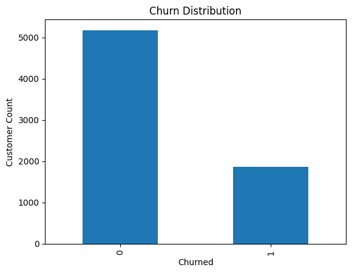

```python
# Overall Churn Distribution: Establishes baseline and Class Imbalance

data_all['churned'].value_counts().plot(kind='bar')
plt.title('Churn Distribution')
plt.xlabel('Churned')
plt.ylabel('Customer Count')

display(data_all['churned'].value_counts())
```

**Graph Interpretation:**

- 26.5% of customers churned
- 73.5% did not churn

## Churn Distribution by Date

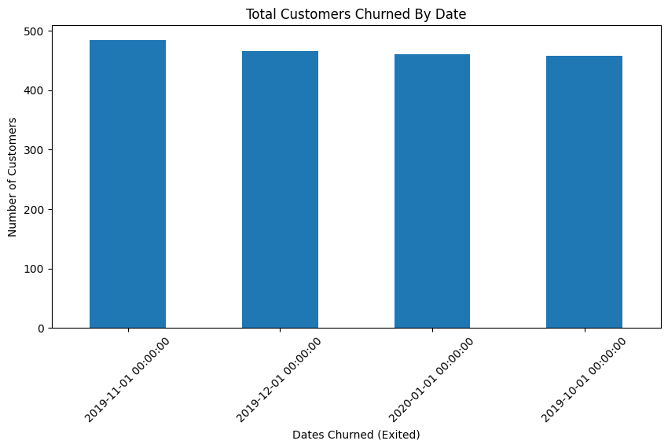

```python
# Which months had the most churn?

churned_months = data_all['end_date'].value_counts()
churned_months.plot(kind='bar', figsize=(10,5))
plt.title("Total Customers Churned By Date")
plt.ylabel("Number of Customers")
plt.xlabel("Dates Churned (Exited)")
plt.xticks(rotation = 45)
plt.show()
```

**Graph Interpretation**

| Month | Churned Customers | Rank |
| --- | --- | --- |
| October 2019 | 458 | 4th |
| November 2019 | 485 | **1st (Highest Churn)** |
| December 2019 | 466 | 2nd |
| January 2020 | 460 | 3rd |

## Churn Distribution by Date & Tenure

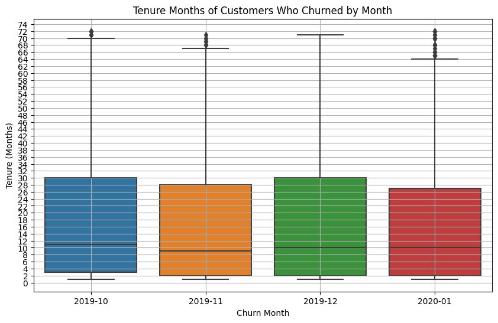

```python
# How does tenure relate to churn?

# Create a month column for easier plotting
churned = data_all[data_all['end_date'].notna()].copy()

churned['churn_month'] = churned['end_date'].dt.to_period('M')

plt.figure(figsize=(10,6))
sns.boxplot(x='churn_month', y='tenure_months', data=churned.sort_values('end_date'))
plt.title('Tenure Months of Customers Who Churned by Month')
plt.xlabel('Churn Month')
plt.ylabel('Tenure (Months)')
plt.grid(True)
plt.yticks(range(0, churned['tenure_months'].max()+4, 2))
plt.show()
```

```python
display(data_all.groupby('end_date')['tenure_months'].agg(['count', 'mean', 'sum','min','median','max']).sort_index())
```

| end_date | count | mean | sum | min | median | max |
| --- | --- | --- | --- | --- | --- | --- |
| 2019-10-01 | 458 | 18.910480 | 8661 | 1 | 11 | 72 |
| 2019-11-01 | 485 | 17.261856 | 8372 | 1 | 9 | 71 |
| 2019-12-01 | 466 | 18.150215 | 8458 | 1 | 10 | 71 |
| 2020-01-01 | 460 | 17.634783 | 8112 | 1 | 10 | 72 |

**Graph Interpretation: Churned Customers by Month**

[output not shown]

**Tenure Months of Churned Customers Summary**

| Metric | Value |
| --- | --- |
| Range | 1-72 |
| IQR Range | 2-30 |
| Median | 9-11 |
| Mean | 17-19 |
| Count | 458-485 |
| Outliers | > 64 |

**Conclusion**

Churn between October 2019 and January 2020 was dominated by customers with relatively short tenure, particularly those within their first year. Notably, approximately 75% of churned customers left within the first 2.5 years, as indicated by the interquartile range of tenure months. While a small number of long-tenured customers also churned, the consistency of tenure distributions across months suggests a broader, systemic issue affecting customer retention rather than isolated customer behavior. These findings indicate that early-stage customer engagement and retention strategies are critical areas for intervention.

## Churn Distribution by Tenure

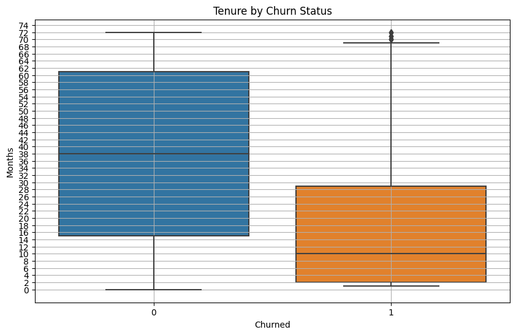

```python
# How does tenure relate to churn?
# Does churn decrease as tenure increases?

plt.figure(figsize=(10,6))
sns.boxplot(x='churned', y='tenure_months', data=data_all)
plt.title('Tenure by Churn Status')
plt.xlabel("Churned")
plt.ylabel("Months")
plt.grid(True)
plt.yticks(range(0,data_all['tenure_months'].max()+4,2))
plt.show()
```

```python
display(data_all.groupby('churned')['tenure_months'].agg(['count', 'mean', 'sum','min','median','max']).sort_index())
```

| churned | count | mean | sum | min | median | max |
| --- | --- | --- | --- | --- | --- | --- |
| 0 | 5174 | 37.569965 | 194387 | 0 | 38 | 72 |
| 1 | 1869 | 17.979133 | 33603 | 1 | 10 | 72 |

**Graph Interpretation: Retention Based on Tenure**

| Churn Status | Range | IQR | Median | Mean | Count | Outliers |
| --- | --- | --- | --- | --- | --- | --- |
| Active | 0-72 | 15-61 | 38 | 37.6 | 5174 | N/A |
| **Not** Active | 1-72 | 2-29 | 10 | 18.0 | 1869 | >69 |

- The distribution of customer tenure differs substantially between active and churned customers.
- Active customers show long and stable tenure, with a median of 38 months and an IQR of 15–61 months, indicating that most retained customers remain for multiple years.
- Churned customers have significantly shorter tenure, with a median of only 10 months and an IQR of 2–29 months, demonstrating that churn is concentrated early in the customer lifecycle.
- The higher mean tenure among churned customers (18 months) compared to the median reflects right-skewness, caused by a small number of long-tenured customers who churn much later.
- Outliers above ~69 months among churned customers suggest that while rare, late-stage churn still occurs.

**Conclusion:**

Customer churn is primarily an early-tenure phenomenon. Analysis shows that churn risk is heavily concentrated within the first ~29 months of tenure, after which customer retention stabilizes significantly. As a result, tenure emerges as one of the strongest predictors of churn, justifying its inclusion as a key feature in modeling. Customers who do not reach approximately 2–2.5 years represent the highest-risk segment and should be prioritized for targeted retention efforts.

## Churn Distribution by Monthly Charges

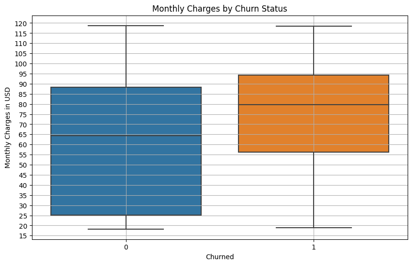

```python
# Monthly Charges vs Churn

plt.figure(figsize=(10,6))
sns.boxplot(x='churned', y='monthly_charges', data=data_all)
plt.title('Monthly Charges by Churn Status')
plt.xlabel("Churned")
plt.ylabel("Monthly Charges in USD")
plt.grid(True)
plt.yticks(range(15,125,5))
plt.show()
```

```python
display(data_all.groupby('churned')['monthly_charges'].agg(['count', 'mean', 'sum','min','median','max']).sort_index())
```

| churned | count | mean | sum | min | median | max |
| --- | --- | --- | --- | --- | --- | --- |
| 0 | 5174 | 61.265124 | 316985.75 | 18.25 | 64.425 | 118.75 |
| 1 | 1869 | 74.441332 | 139130.85 | 18.85 | 79.650 | 118.35 |

**Graph Interpretation: Retention Based on Monthly Charges**

| Churn Status | Range | IQR | Median | Mean | Count | Outliers |
| --- | --- | --- | --- | --- | --- | --- |
| Active | 18-119 | 25-88 | 64.4 | 61.3 | 5174 | N/A |
| **Not** Active | 19-118 | 56-95 | 79.7 | 74.4 | 1869 | N/A |

**Warning:**

- The graph starts around 15 USD
- The values in the markdown chart are approximate values

**Conclusion:**

Churned customers exhibit consistently higher monthly charges compared to active customers. While both groups span a similar overall price range, their central tendencies differ meaningfully:

- The median monthly charge for churned customers (≈ 80 USD) is substantially higher than that of active customers (≈ 64 USD).
- The interquartile range (IQR) for churned customers (≈ 56–95 USD) is shifted upward relative to active customers (≈ 25–88 USD), indicating that the middle 50% of churn occurs at higher price points.
- The mean monthly charge is also higher for churned customers, reinforcing that this is not driven by a small number of extreme cases.

This pattern suggests that higher monthly charges are associated with increased churn risk, potentially reflecting:

- Perceived lack of value at higher price tiers
- Service complexity or add-ons increasing friction
- Higher expectations among premium customers

Retention strategies should prioritize high-paying customers, particularly those early in their tenure, by reinforcing value, improving onboarding, or offering targeted incentives before dissatisfaction leads to churn.

## Integrated: Tenure, Monthly Charges, and Churn

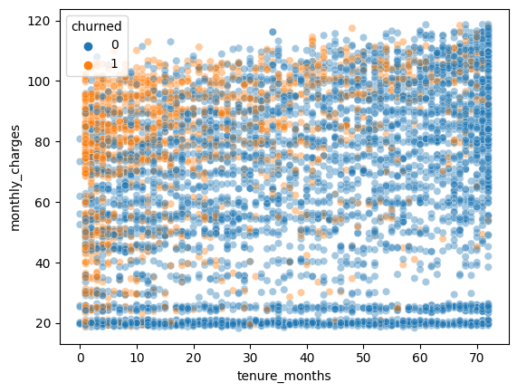

```python
# Tenure vs Monthly Charges (Interaction)
sns.scatterplot(
    x='tenure_months',
    y='monthly_charges',
    hue='churned',
    data=data_all,
    alpha=0.4
)
```

**Integrated Interpretation: Monthly Charges, Tenure, and Churn**

**Monthly Charges:**

| Churn Status | Range | IQR | Median | Mean | Count | Outliers |
| --- | --- | --- | --- | --- | --- | --- |
| Active | 18-119 | 25-88 | 64.4 | 61.3 | 5174 | N/A |
| **Not** Active | 19-118 | 56-95 | 79.7 | 74.4 | 1869 | N/A |

**Tenure:**

| Churn Status | Range | IQR | Median | Mean | Count | Outliers |
| --- | --- | --- | --- | --- | --- | --- |
| Active | 0-72 | 15-61 | 38 | 37.6 | 5174 | N/A |
| **Not** Active | 1-72 | 2-29 | 10 | 18.0 | 1869 | >69 |

**Key Insights:**

**Conclusion**

Churned customers tend to pay more than active customers, as reflected in higher medians and IQRs for monthly charges. The scatterplot clarifies that churn is primarily an early-tenure phenomenon, with most churn occurring within the first 25–30 months. High monthly charges amplify churn risk in this early period, while tenure beyond this window strongly stabilizes retention. Retention strategies should therefore focus on early-stage, higher-value customers, as they are both the most price-sensitive and the most likely to churn.

## Churn Rate by Contract Type

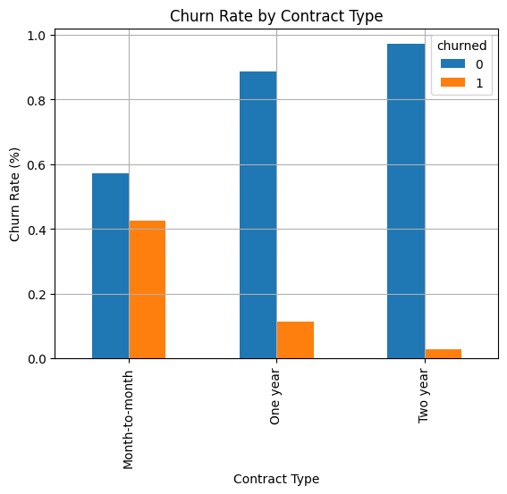

```python
# Churn by contract type

plt.figure(figsize=(10,6))
pd.crosstab(data_all['type'], data_all['churned'], normalize='index').plot(kind='bar')
plt.title('Churn Rate by Contract Type')
plt.xlabel("Contract Type")
plt.ylabel("Churn Rate (%)")
plt.grid(True)
plt.show()
```

**Graph Interpretation: Retention Based on Contract Type**

| Contract Type | Status | Rate (%) |
| --- | --- | --- |
| Month-to-month | Active | 55-59 |
| Month-to-month | **Not** | 40-45 |
| One year | Active | 85-90 |
| One year | **Not** | 10-15 |
| Two year | Active | 95-99 |
| Two year | **Not** | 1-5 |

**Warning:**

- Values in markdown chart are approximations

**Conclustion:**

Customer retention varies dramatically by contract type, with contract length emerging as one of the strongest indicators of churn risk.

- Month-to-month contracts show the highest churn rates, with approximately 40–45% of customers churning, indicating minimal commitment and high flexibility to exit.
- One-year contracts demonstrate substantially higher retention, with 85–90% of customers remaining active, suggesting that even moderate contractual commitment significantly reduces churn.
- Two-year contracts exhibit the strongest retention outcomes, with 95–99% of customers remaining active and churn rates as low as 1–5%, reflecting high customer stability.

Customers on month-to-month contracts are significantly more likely to churn, while longer contract durations strongly correlate with customer retention, making contract type one of the most predictive features for churn.

## Churn Rate by Payment Method

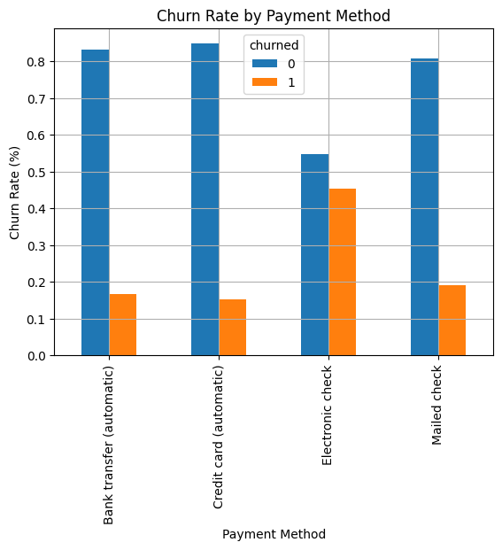

```python
# Payment Method vs Churn

plt.figure(figsize=(10,6))
pd.crosstab(data_all['payment_method'], data_all['churned'], normalize='index').plot(kind='bar')
plt.title('Churn Rate by Payment Method')
plt.xlabel("Payment Method")
plt.ylabel("Churn Rate (%)")
plt.grid(True)
plt.show()
```

**Graph Interpretation: Retention Based on Payment Method**

| Payment Method | Status | Rate (%) |
| --- | --- | --- |
| Electronic Check | Active | 55 |
| Electronic Check | **Not** | 45 |
| Mailed Check | Active | 80 |
| Mailed Check | **Not** | 20 |
| Bank Transfer (automatic) | Active | 83 |
| Bank Transfer (automatic) | **Not** | 17 |
| Credit Card (automatic) | Active | 85 |
| Credit Card (automatic) | **Not** | 15 |

**Warning:**

- Values in the markdown chart are approximation

**Conclusion:**

Customer churn varies notably by payment method, with Electronic Check standing out as a high-risk segment.

- Customers using Electronic Check exhibit the highest churn rate at approximately 45%, substantially higher than any other payment method.
- In contrast, Mailed Check, Bank Transfer (automatic), and Credit Card (automatic) show significantly stronger retention, with churn rates clustering around 15–20%.
- Automatic payment methods in particular demonstrate consistently higher retention, suggesting greater customer stability.

Customers paying via Electronic Check exhibit significantly higher churn rates than those using other payment methods, making payment method a strong behavioral predictor of customer retention.

## Integrated: Type, Tenure, and Payment Method

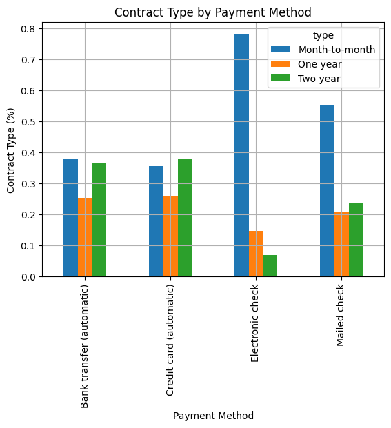

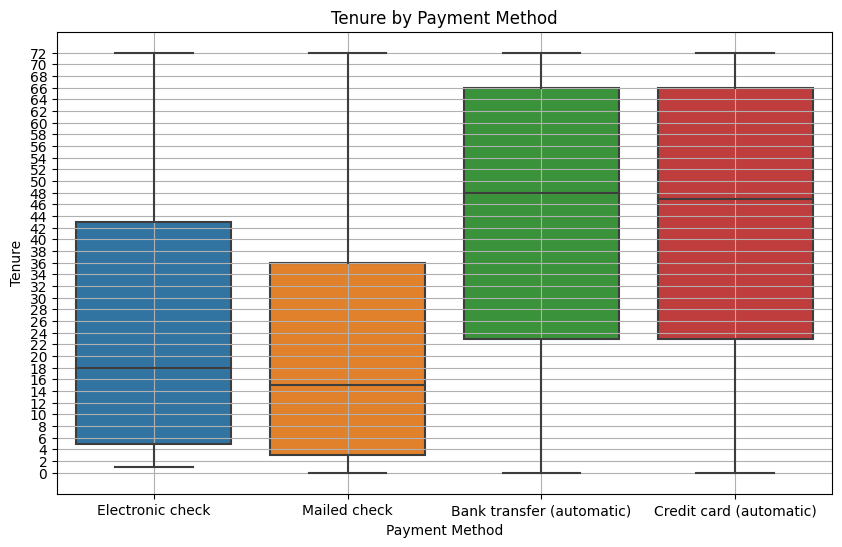

```python
# Payment Method vs Contract Type
plt.figure(figsize=(10,6))
pd.crosstab(data_all['payment_method'], data_all['type'], normalize='index').plot(kind='bar')
plt.title('Contract Type by Payment Method')
plt.xlabel("Payment Method")
plt.ylabel("Contract Type (%)")
plt.grid(True)
plt.show()

# Payment Method vs. Tensure
plt.figure(figsize=(10,6))
sns.boxplot(x='payment_method', y='tenure_months', data= data_all)
plt.title('Tenure by Payment Method')
plt.xlabel("Payment Method")
plt.ylabel("Tenure")
plt.grid(True)
plt.yticks(range(0,74,2))
plt.show()
```

```python
display(data_all.groupby('payment_method')['tenure_months'].agg(['count', 'mean', 'sum','min','median','max']).sort_index())
```

| payment_method | count | mean | sum | min | median | max |
| --- | --- | --- | --- | --- | --- | --- |
| Bank transfer (automatic) | 1544 | 43.656736 | 67406 | 0 | 48 | 72 |
| Credit card (automatic) | 1522 | 43.269382 | 65856 | 0 | 47 | 72 |
| Electronic check | 2365 | 25.174630 | 59538 | 1 | 18 | 72 |
| Mailed check | 1612 | 21.830025 | 35190 | 0 | 15 | 72 |

**Integrated Interpretation: Payment Method, Contract Type, Tenure, and Churn:**

**1. Contract Type Strongly Differs by Payment Method**

| Payment Method | Contract Type | Contract Rate (%) |
| --- | --- | --- |
| Electronic Check | Month-to-month | 75-79 |
| Electronic Check | One year | 12-17 |
| Electronic Check | Two year | 5-9 |
| Mailed Check | Month-to-month | 52-57 |
| Mailed Check | One year | 20-23 |
| Mailed Check | Two year | 21-25 |
| Bank Transfer (automatic) | Month-to-month | 35-39 |
| Bank Transfer (automatic) | One year | 22-27 |
| Bank Transfer (automatic) | Two year | 35-39 |
| Credit Card (automatic) | Month-to-month | 32-37 |
| Credit Card (automatic) | One year | 25-29 |
| Credit Card (automatic) | Two year | 35-39 |

Customers using Electronic Check are overwhelmingly concentrated in month-to-month contracts, with approximately 75–79% of these customers on short-term agreements. In contrast:

- Automatic payment methods (Bank Transfer and Credit Card) show a much more balanced distribution across contract types.
- Long-term contracts (two-year) are substantially more common among customers using automatic payments.

This indicates that Electronic Check users are structurally more exposed to churn risk due to their contract composition alone.

**2. Tenure Profiles Reinforce the Risk Concentration**

| Payment Method | Tenure Range | IQR | Median | Mean | Count | Outliers |
| --- | --- | --- | --- | --- | --- | --- |
| Electronic Check | 1-72 | 5-43 | 18 | 25.2 | 2365 | N/A |
| Mailed Check | 0-72 | 3-36 | 15 | 21.8 | 1612 | N/A |
| Bank Transfer (automatic) | 0-72 | 23-66 | 48 | 43.7 | 1544 | N/A |
| Credit Card (automatic) | 0-72 | 23-66 | 47 | 43.3 | 1522 | N/A |

Tenure distributions further support this pattern:

- Electronic Check customers have:
  - A lower median tenure (18 months)
  - A narrower IQR (5–43 months)
  - A substantially lower mean tenure (25.2 months)
- Customers using automatic payment methods (Bank Transfer and Credit Card) exhibit:
  - Median tenures near 47–48 months
  - Much higher IQR ranges (23–66 months)
  - Longer overall customer lifetimes

This suggests that Electronic Check customers are earlier in their customer lifecycle, where churn risk is already known to be highest.

**3. Retention Outcomes Align with Contract and Tenure Patterns**

| Payment Method | Status | Rate (%) |
| --- | --- | --- |
| Electronic Check | Active | 55 |
| Electronic Check | **Not** | 45 |
| Mailed Check | Active | 80 |
| Mailed Check | **Not** | 20 |
| Bank Transfer (automatic) | Active | 83 |
| Bank Transfer (automatic) | **Not** | 17 |
| Credit Card (automatic) | Active | 85 |
| Credit Card (automatic) | **Not** | 15 |

The retention rates closely mirror the structural differences observed above:

- Electronic Check has the highest churn rate at ~45%
- Other payment methods cluster between 15–20% churn
- Automatic payments consistently show the strongest retention

Importantly, the elevated churn among Electronic Check users appears to be partially explained by their shorter tenure and heavy reliance on month-to-month contracts, rather than payment method alone.

**Conclusion:**

Customers using Electronic Check represent a high-risk churn segment largely due to their concentration in month-to-month contracts and shorter tenure profiles. Payment method, contract type, and tenure are highly interrelated, and their combined effect drives significantly higher churn rates among Electronic Check users.

## Churn Rate by Tech Support

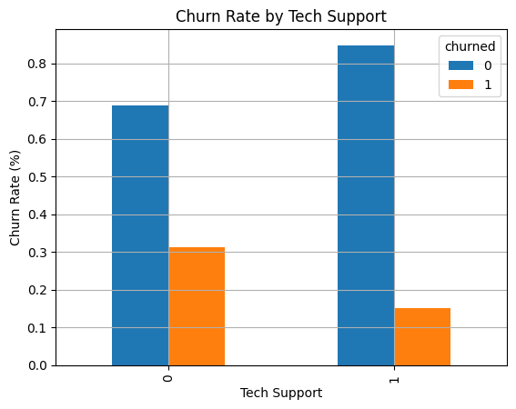

```python
# Tech Support vs. Churn
plt.figure(figsize=(10,6))
pd.crosstab(data_all['tech_support'], data_all['churned'], normalize='index').plot(kind='bar')
plt.title('Churn Rate by Tech Support')
plt.xlabel("Tech Support")
plt.ylabel("Churn Rate (%)")
plt.grid(True)
plt.show()
```

**Graph Interpretation: Retention Based on Tech Support**

| Tech Support | Status | Rate (%) |
| --- | --- | --- |
| No | Active | 68-70 |
| No | **Not** | 30-33 |
| Yes | Active | 82-87 |
| Yes | **Not** | 12-17 |

Customers with tech support show significantly higher retention compared to those without it.

- Customers without tech support have a churn rate of approximately 30–33%
- Customers with tech support churn at a much lower rate of 12–17%
- This represents roughly a 2× higher churn risk for customers who do not have tech support

**Conclusion:**

Customers with tech support are significantly more likely to remain active, suggesting that service quality and support access play a critical role in reducing churn.

## Churn Rate by Senior Citizen

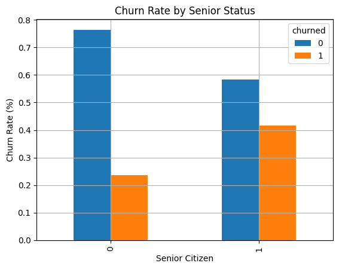

```python
# Senior Citizen vs Churn

plt.figure(figsize=(10,6))
pd.crosstab(data_all['senior_citizen'], data_all['churned'], normalize='index').plot(kind='bar')
plt.title('Churn Rate by Senior Status')
plt.xlabel("Senior Citizen")
plt.ylabel("Churn Rate (%)")
plt.grid(True)
plt.show()
```

**Graph Interpretation: Retention Based on Senior Citizen Status**

| Senior Citizen | Status | Rate (%) |
| --- | --- | --- |
| No | Active | 75-79 |
| No | **Not** | 21-25 |
| Yes | Active | 56-60 |
| Yes | **Not** | 40-44 |

Senior citizens exhibit a substantially higher churn rate compared to non-senior customers.

- Non-senior customers churn at a rate of approximately 21–25%
- Senior citizens churn at a much higher rate of 40–44%
- This represents nearly a 2× increase in churn risk for senior customers

**Hypothesis:** The elevated churn rate among senior citizens may be partially explained by lower access to or usage of tech support, leading to unresolved technical issues and customer frustration.

**Conclusion:**

Senior citizens churn at nearly twice the rate of non-senior customers, suggesting unmet support needs that may be mitigated through targeted technical assistance.

```python
# Validate if Senior Citizens tend to Churn b/c of lack of tech support

pd.crosstab(data_all['senior_citizen'], data_all['tech_support'], normalize='index')
```

| tech_support senior_citizen | 0 | 1 |
| --- | --- | --- |
| 0 | 0.697678 | 0.302322 |
| 1 | 0.772329 | 0.227671 |

**Integrated Interpretation: Senior Citizen, Tech Support, and Churn:**

| Senior Citizen | Tech Support | Tech Support (%) |
| --- | --- | --- |
| No | No | 70 |
| No | Yes | 30 |
| Yes | No | 77 |
| Yes | Yes | 23 |

| Senior Citizen | Status | Rate (%) |
| --- | --- | --- |
| No | Active | 75-79 |
| No | **Not** | 21-25 |
| Yes | Active | 56-60 |
| Yes | **Not** | 40-44 |

Senior citizens churn at nearly twice the rate of non-senior customers and are also significantly less likely to subscribe to tech support. Given the strong retention benefits associated with tech support, this suggests that limited access to or usage of technical assistance may be contributing to higher churn among senior customers.

- Senior citizens are less likely to have tech support
  - Only 23% of senior customers have tech support
  - Compared to 30% among non-seniors
- Seniors are 7 percentage points more likely to lack tech support
- This aligns closely with:
  - Higher churn among seniors (40–44%)
  - Lower churn among customers with tech support (12–17%)

**Conclusion:**

The higher churn rate observed among senior citizens appears to be partially associated with lower adoption of tech support services. While this analysis does not establish causation, it highlights a plausible contributing factor supported by the data. Senior customers are both more likely to churn and less likely to use tech support, suggesting that targeted support initiatives for seniors could meaningfully improve customer retention

## Linear Correlations

```python
# Using .corr() to show linear relationships
data_all.corr()
```

|  | paperless_billing | monthly_charges | total_charges | begin_month | begin_year | churned | tenure_months | gender | senior_citizen | partner | dependents | internet_service | online_security | online_backup | device_protection | tech_support | streaming_tv | streaming_movies | multiple_lines |
| --- | --- | --- | --- | --- | --- | --- | --- | --- | --- | --- | --- | --- | --- | --- | --- | --- | --- | --- | --- |
| paperless_billing | 1.000000 | 0.352150 | 0.158574 | 0.024053 | -0.019011 | 0.191825 | 0.006152 | -0.011754 | 0.156530 | -0.014877 | -0.111377 | -0.063121 | -0.003636 | 0.126735 | 0.103797 | 0.037880 | 0.223841 | 0.211716 | 0.163530 |
| monthly_charges | 0.352150 | 1.000000 | 0.651174 | -0.018072 | -0.264251 | 0.193356 | 0.247900 | -0.014569 | 0.220173 | 0.096848 | -0.113890 | -0.160189 | 0.296594 | 0.441780 | 0.482692 | 0.338304 | 0.629603 | 0.627429 | 0.490434 |
| total_charges | 0.158574 | 0.651174 | 1.000000 | -0.194289 | -0.819539 | -0.198324 | 0.826178 | -0.000080 | 0.103006 | 0.317504 | 0.062078 | -0.052469 | 0.411651 | 0.509226 | 0.521983 | 0.431883 | 0.514973 | 0.520122 | 0.468504 |
| begin_month | 0.024053 | -0.018072 | -0.194289 | 1.000000 | 0.081542 | 0.181417 | -0.230371 | -0.003223 | 0.029381 | -0.131669 | -0.067989 | -0.024386 | -0.103943 | -0.073651 | -0.092586 | -0.095653 | -0.059497 | -0.068723 | -0.077022 |
| begin_year | -0.019011 | -0.264251 | -0.819539 | 0.081542 | 1.000000 | 0.291621 | -0.987428 | -0.004386 | -0.028418 | -0.367419 | -0.148000 | -0.004111 | -0.316448 | -0.359148 | -0.357400 | -0.314811 | -0.284914 | -0.289747 | -0.335494 |
| churned | 0.191825 | 0.193356 | -0.198324 | 0.181417 | 0.291621 | 1.000000 | -0.352229 | -0.008612 | 0.150889 | -0.150448 | -0.164221 | -0.124214 | -0.171226 | -0.082255 | -0.066160 | -0.164674 | 0.063228 | 0.061382 | 0.040102 |
| tenure_months | 0.006152 | 0.247900 | 0.826178 | -0.230371 | -0.987428 | -0.352229 | 1.000000 | 0.005106 | 0.016567 | 0.379697 | 0.159712 | 0.013274 | 0.327203 | 0.360277 | 0.360653 | 0.324221 | 0.279756 | 0.286111 | 0.331941 |
| gender | -0.011754 | -0.014569 | -0.000080 | -0.003223 | -0.004386 | -0.008612 | 0.005106 | 1.000000 | -0.001874 | -0.001808 | 0.010517 | 0.006568 | -0.017021 | -0.013773 | -0.002105 | -0.009212 | -0.008393 | -0.010487 | -0.008414 |
| senior_citizen | 0.156530 | 0.220173 | 0.103006 | 0.029381 | -0.028418 | 0.150889 | 0.016567 | -0.001874 | 1.000000 | 0.016479 | -0.211185 | -0.108322 | -0.038653 | 0.066572 | 0.059428 | -0.060625 | 0.105378 | 0.120176 | 0.142948 |
| partner | -0.014877 | 0.096848 | 0.317504 | -0.131669 | -0.367419 | -0.150448 | 0.379697 | -0.001808 | 0.016479 | 1.000000 | 0.452676 | -0.000851 | 0.143106 | 0.141498 | 0.153786 | 0.119999 | 0.124666 | 0.117412 | 0.142057 |
| dependents | -0.111377 | -0.113890 | 0.062078 | -0.067989 | -0.148000 | -0.164221 | 0.159712 | 0.010517 | -0.211185 | 0.452676 | 1.000000 | 0.052010 | 0.080972 | 0.023671 | 0.013963 | 0.063268 | -0.016558 | -0.039741 | -0.024526 |
| internet_service | -0.063121 | -0.160189 | -0.052469 | -0.024386 | -0.004111 | -0.124214 | 0.013274 | 0.006568 | -0.108322 | -0.000851 | 0.052010 | 1.000000 | 0.321269 | 0.157884 | 0.146291 | 0.313118 | 0.016274 | 0.025698 | -0.199920 |
| online_security | -0.003636 | 0.296594 | 0.411651 | -0.103943 | -0.316448 | -0.171226 | 0.327203 | -0.017021 | -0.038653 | 0.143106 | 0.080972 | 0.321269 | 1.000000 | 0.283832 | 0.275438 | 0.354931 | 0.176207 | 0.187398 | 0.098108 |
| online_backup | 0.126735 | 0.441780 | 0.509226 | -0.073651 | -0.359148 | -0.082255 | 0.360277 | -0.013773 | 0.066572 | 0.141498 | 0.023671 | 0.157884 | 0.283832 | 1.000000 | 0.303546 | 0.294233 | 0.282106 | 0.274501 | 0.202237 |
| device_protection | 0.103797 | 0.482692 | 0.521983 | -0.092586 | -0.357400 | -0.066160 | 0.360653 | -0.002105 | 0.059428 | 0.153786 | 0.013963 | 0.146291 | 0.275438 | 0.303546 | 1.000000 | 0.333313 | 0.390874 | 0.402111 | 0.201137 |
| tech_support | 0.037880 | 0.338304 | 0.431883 | -0.095653 | -0.314811 | -0.164674 | 0.324221 | -0.009212 | -0.060625 | 0.119999 | 0.063268 | 0.313118 | 0.354931 | 0.294233 | 0.333313 | 1.000000 | 0.278070 | 0.279358 | 0.100571 |
| streaming_tv | 0.223841 | 0.629603 | 0.514973 | -0.059497 | -0.284914 | 0.063228 | 0.279756 | -0.008393 | 0.105378 | 0.124666 | -0.016558 | 0.016274 | 0.176207 | 0.282106 | 0.390874 | 0.278070 | 1.000000 | 0.533094 | 0.257152 |
| streaming_movies | 0.211716 | 0.627429 | 0.520122 | -0.068723 | -0.289747 | 0.061382 | 0.286111 | -0.010487 | 0.120176 | 0.117412 | -0.039741 | 0.025698 | 0.187398 | 0.274501 | 0.402111 | 0.279358 | 0.533094 | 1.000000 | 0.258751 |
| multiple_lines | 0.163530 | 0.490434 | 0.468504 | -0.077022 | -0.335494 | 0.040102 | 0.331941 | -0.008414 | 0.142948 | 0.142057 | -0.024526 | -0.199920 | 0.098108 | 0.202237 | 0.201137 | 0.100571 | 0.257152 | 0.258751 | 1.000000 |

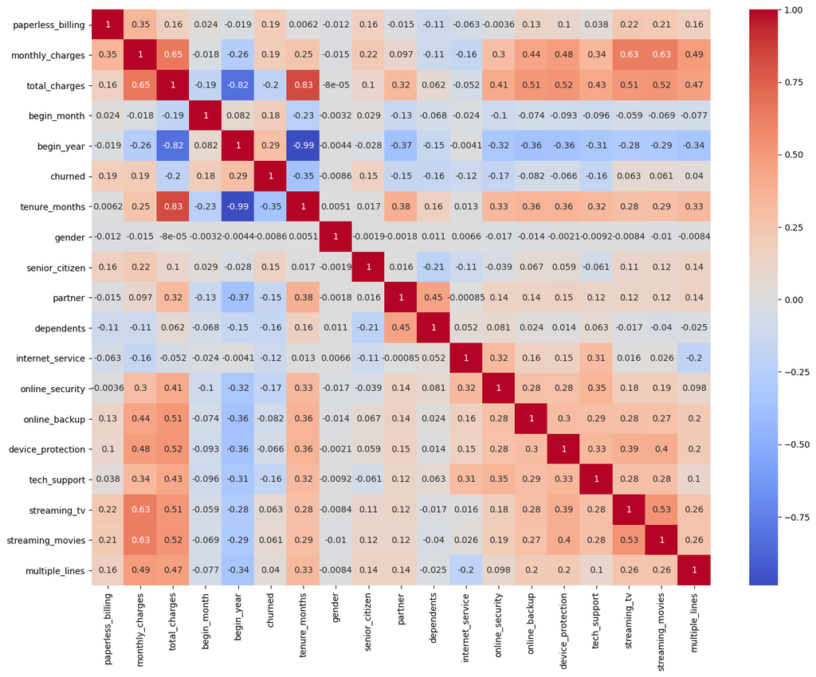

```python
# Heatmap
# `annot=True`: shows exact correlation values (like 0.73 or -0.21) on top of each colored square (without it, the numbers would not be there)
plt.figure(figsize=(16,12))
sns.heatmap(data_all.corr(), annot=True, cmap='coolwarm')
plt.show()
```

**Most Significant Linear Relationships for each Feature:**

| Main Feature | Relating Features | Positive Correlation Value | Relating Feature | Negative Correlation Value |
| --- | --- | --- | --- | --- |
| Paperless Billing | Monthly Charges | 0.35 | Dependents | -0.11 |
| Monthly Charges | Total Charges | 0.65 | Begin Year | -0.26 |
| Total Charges | Tenure Months | 0.83 (**highest**) | Begin Year | -0.82 |
| Begin Month | Churned | 0.18 | Tenure Months | -0.23 |
| Begin Year | Churned | 0.29 | Tenure Months | -0.99 (**lowest**) |
| Churned | Begin Year | 0.29 | Tenure Months | -0.35 |
| Tenure Months | Total Charges | 0.83 (**highest**) | Begin Year | -0.99 (**lowest**) |
| Gender | Dependents | 0.011 | Online Security | -0.017 |
| Senior Citizen | Monthly Charges | 0.22 | Dependents | -0.21 |
| Partner | Dependents | 0.45 | Begin Year | -0.37 |
| Dependents | Partner | 0.45 | Senior Citizen | -0.21 |
| Internet Service | Online Security | 0.32 | Multiple Lines | -0.2 |
| Online Security | Total Charges | 0.41 | Begin Year | -0.32 |
| Online Backup | Total Charges | 0.51 | Begin Year | -0.36 |
| Device Protection | Total Charges | 0.52 | Begin Year | -0.36 |
| Tech Support | Total Charges | 0.43 | Begin Year | -0.31 |
| Streaming TV | Monthly Charges | 0.63 | Begin Year | -0.28 |
| Streaming Movies | Monthly Charges | 0.63 | Begin Year | -0.29 |
| Multiple Lines | Monthly Charges | 0.49 | Begin Year | -0.34 |

**This table** shows which features move together:

- **Positive correlations:** Features that tend to increase together.
  - TotalCharges ↔ TenureMonths (0.83) → Makes sense: the longer a customer stays, the more total charges accumulate.
  - MonthlyCharges ↔ Streaming TV/Movies (0.63) → Streaming add-ons increase monthly charges.
- **Negative correlations:** Features that move in opposite directions.
  - TenureMonths ↔ BeginYear (-0.99) → Newer customers have shorter tenure (obvious but confirms data integrity).

**Linear Relationships with Churned Feature:**

[output not shown]

| Feature | Correlation with Churn | Interpretation |
| --- | --- | --- |
| **Tenure Months (-0.35)** | Strongest negative | Customers with **longer tenure are much less likely to churn** — early churn is the biggest risk. |
| **Begin Year (0.29)** | Strongest positive | Customers who started more recently are **more likely to churn**, reflecting newer customers’ higher risk. |
| **Monthly Charges & Paperless Billing (~0.19)** | Moderate positive | Customers paying higher monthly charges or using paperless billing are **slightly more likely to churn**. |
| **Senior Citizen (0.15)** | Weak positive | Seniors have a slightly higher churn risk. |
| **Partner / Dependents (-0.15, -0.16)** | Weak negative | Having a partner or dependents slightly reduces churn risk. |
| **Other features (<0.1) ** | Negligible | Gender, streaming habits, device protection, etc., have very weak linear relationships with churn. |

**Summary:**

- Tenure and Begin Year are the most important numeric predictors.
- Monthly Charges also matters, but less than tenure.
- Categorical or binary features may not show strong linear correlation but can still be predictive when encoded (e.g., PaperlessBilling, ContractType, TechSupport).

**Key Findings:**

**1. High-impact numeric features:**

- TenureMonths, BeginYear, MonthlyCharges, TotalCharges (careful with collinearity).

**2. Categorical / binary features still important:**

- PaperlessBilling, ContractType, PaymentMethod, TechSupport, SeniorCitizen.
- Correlation won’t show much, but they’re clearly linked to churn shown by earlier EDA visualization.

**3. Features with very low linear correlation (<0.1)** are unlikely to help by themselves, but could still contribute in combination with others.